# Part I - (Prosper Loan Dataset)

## Introduction

Exploration of Prosper Loan Dataset. Prosper a is platform that allow individual to post Loan request, and based on some criteria Prosper determine the risk of the request and provide such information for individual investors to access the listing and meet the requirment of the request/Listing.

The Dataset consist of 113,937 loan request/listing with 81 properties/features associated with each listing such as :

- ListingNumber - The number that uniquely identifies the listing to the public as displayed on the website.
- Term - The length of the loan expressed in months.
- LoanStatus - The current status of the loan: Cancelled, Chargedoff, Completed, Current, Defaulted, PastDue.
- BorrowerRate - The Borrower's interest rate for this loan.
- Occupation - The Borrower's Occupation

## Preliminary Wrangling

```python
# import all packages and set plots to be embedded inline
import numpy as np
import pandas as pd
import matplotlib.pyplot as plt
#from matplotlib import rcParams
import seaborn as sb

%matplotlib inline
```

> Load in your dataset and describe its properties through the questions below. Try and motivate your exploration goals through this section.

```python
# Reading the dataset

df = pd.read_csv('prosperLoanData.csv')
```

```python
df.shape
```

```
(113937, 81)
```

```python
# Making copy of the dataset

dfc= df.copy()
```

```python
df.info()
```

```
<class 'pandas.core.frame.DataFrame'>
RangeIndex: 113937 entries, 0 to 113936
Data columns (total 81 columns):
 #   Column                               Non-Null Count   Dtype
---  ------                               --------------   -----
 0   ListingKey                           113937 non-null  object
 1   ListingNumber                        113937 non-null  int64
 2   ListingCreationDate                  113937 non-null  object
 3   CreditGrade                          28953 non-null   object
 4   Term                                 113937 non-null  int64
 5   LoanStatus                           113937 non-null  object
 6   ClosedDate                           55089 non-null   object
 7   BorrowerAPR                          113912 non-null  float64
 8   BorrowerRate                         113937 non-null  float64
 9   LenderYield                          113937 non-null  float64
```

[output cut: 73 more lines]

```python
# Converting some features to datetime datatype

dfc.ListingCreationDate=dfc.ListingCreationDate.apply(np.datetime64)
dfc.LoanOriginationDate=dfc.LoanOriginationDate.apply(np.datetime64)
dfc.DateCreditPulled=dfc.DateCreditPulled.apply(np.datetime64)
```

```python
# descriptive staticstic of the dataset

dfc.describe()
```

|  | ListingNumber | Term | BorrowerAPR | BorrowerRate | LenderYield | EstimatedEffectiveYield | EstimatedLoss | EstimatedReturn | ProsperRating (numeric) | ProsperScore | ... | LP_ServiceFees | LP_CollectionFees | LP_GrossPrincipalLoss | LP_NetPrincipalLoss | LP_NonPrincipalRecoverypayments | PercentFunded | Recommendations | InvestmentFromFriendsCount | InvestmentFromFriendsAmount | Investors |
| --- | --- | --- | --- | --- | --- | --- | --- | --- | --- | --- | --- | --- | --- | --- | --- | --- | --- | --- | --- | --- | --- |
| count | 1.139370e+05 | 113937.000000 | 113912.000000 | 113937.000000 | 113937.000000 | 84853.000000 | 84853.000000 | 84853.000000 | 84853.000000 | 84853.000000 | ... | 113937.000000 | 113937.000000 | 113937.000000 | 113937.000000 | 113937.000000 | 113937.000000 | 113937.000000 | 113937.000000 | 113937.000000 | 113937.000000 |
| mean | 6.278857e+05 | 40.830248 | 0.218828 | 0.192764 | 0.182701 | 0.168661 | 0.080306 | 0.096068 | 4.072243 | 5.950067 | ... | -54.725641 | -14.242698 | 700.446342 | 681.420499 | 25.142686 | 0.998584 | 0.048027 | 0.023460 | 16.550751 | 80.475228 |
| std | 3.280762e+05 | 10.436212 | 0.080364 | 0.074818 | 0.074516 | 0.068467 | 0.046764 | 0.030403 | 1.673227 | 2.376501 | ... | 60.675425 | 109.232758 | 2388.513831 | 2357.167068 | 275.657937 | 0.017919 | 0.332353 | 0.232412 | 294.545422 | 103.239020 |
| min | 4.000000e+00 | 12.000000 | 0.006530 | 0.000000 | -0.010000 | -0.182700 | 0.004900 | -0.182700 | 1.000000 | 1.000000 | ... | -664.870000 | -9274.750000 | -94.200000 | -954.550000 | 0.000000 | 0.700000 | 0.000000 | 0.000000 | 0.000000 | 1.000000 |
| 25% | 4.009190e+05 | 36.000000 | 0.156290 | 0.134000 | 0.124200 | 0.115670 | 0.042400 | 0.074080 | 3.000000 | 4.000000 | ... | -73.180000 | 0.000000 | 0.000000 | 0.000000 | 0.000000 | 1.000000 | 0.000000 | 0.000000 | 0.000000 | 2.000000 |
| 50% | 6.005540e+05 | 36.000000 | 0.209760 | 0.184000 | 0.173000 | 0.161500 | 0.072400 | 0.091700 | 4.000000 | 6.000000 | ... | -34.440000 | 0.000000 | 0.000000 | 0.000000 | 0.000000 | 1.000000 | 0.000000 | 0.000000 | 0.000000 | 44.000000 |
| 75% | 8.926340e+05 | 36.000000 | 0.283810 | 0.250000 | 0.240000 | 0.224300 | 0.112000 | 0.116600 | 5.000000 | 8.000000 | ... | -13.920000 | 0.000000 | 0.000000 | 0.000000 | 0.000000 | 1.000000 | 0.000000 | 0.000000 | 0.000000 | 115.000000 |
| max | 1.255725e+06 | 60.000000 | 0.512290 | 0.497500 | 0.492500 | 0.319900 | 0.366000 | 0.283700 | 7.000000 | 11.000000 | ... | 32.060000 | 0.000000 | 25000.000000 | 25000.000000 | 21117.900000 | 1.012500 | 39.000000 | 33.000000 | 25000.000000 | 1189.000000 |

8 rows × 61 columns

```python
# viewing first five rows

dfc.head()
```

|  | ListingKey | ListingNumber | ListingCreationDate | CreditGrade | Term | LoanStatus | ClosedDate | BorrowerAPR | BorrowerRate | LenderYield | ... | LP_ServiceFees | LP_CollectionFees | LP_GrossPrincipalLoss | LP_NetPrincipalLoss | LP_NonPrincipalRecoverypayments | PercentFunded | Recommendations | InvestmentFromFriendsCount | InvestmentFromFriendsAmount | Investors |
| --- | --- | --- | --- | --- | --- | --- | --- | --- | --- | --- | --- | --- | --- | --- | --- | --- | --- | --- | --- | --- | --- |
| 0 | 1021339766868145413AB3B | 193129 | 2007-08-26 19:09:29.263000000 | C | 36 | Completed | 2009-08-14 00:00:00 | 0.16516 | 0.1580 | 0.1380 | ... | -133.18 | 0.0 | 0.0 | 0.0 | 0.0 | 1.0 | 0 | 0 | 0.0 | 258 |
| 1 | 10273602499503308B223C1 | 1209647 | 2014-02-27 08:28:07.900000000 | NaN | 36 | Current | NaN | 0.12016 | 0.0920 | 0.0820 | ... | 0.00 | 0.0 | 0.0 | 0.0 | 0.0 | 1.0 | 0 | 0 | 0.0 | 1 |
| 2 | 0EE9337825851032864889A | 81716 | 2007-01-05 15:00:47.090000000 | HR | 36 | Completed | 2009-12-17 00:00:00 | 0.28269 | 0.2750 | 0.2400 | ... | -24.20 | 0.0 | 0.0 | 0.0 | 0.0 | 1.0 | 0 | 0 | 0.0 | 41 |
| 3 | 0EF5356002482715299901A | 658116 | 2012-10-22 11:02:35.010000000 | NaN | 36 | Current | NaN | 0.12528 | 0.0974 | 0.0874 | ... | -108.01 | 0.0 | 0.0 | 0.0 | 0.0 | 1.0 | 0 | 0 | 0.0 | 158 |
| 4 | 0F023589499656230C5E3E2 | 909464 | 2013-09-14 18:38:39.097000000 | NaN | 36 | Current | NaN | 0.24614 | 0.2085 | 0.1985 | ... | -60.27 | 0.0 | 0.0 | 0.0 | 0.0 | 1.0 | 0 | 0 | 0.0 | 20 |

5 rows × 81 columns

```python
# viewing last 5 rows

dfc.tail()
```

|  | ListingKey | ListingNumber | ListingCreationDate | CreditGrade | Term | LoanStatus | ClosedDate | BorrowerAPR | BorrowerRate | LenderYield | ... | LP_ServiceFees | LP_CollectionFees | LP_GrossPrincipalLoss | LP_NetPrincipalLoss | LP_NonPrincipalRecoverypayments | PercentFunded | Recommendations | InvestmentFromFriendsCount | InvestmentFromFriendsAmount | Investors |
| --- | --- | --- | --- | --- | --- | --- | --- | --- | --- | --- | --- | --- | --- | --- | --- | --- | --- | --- | --- | --- | --- |
| 113932 | E6D9357655724827169606C | 753087 | 2013-04-14 05:55:02.663000000 | NaN | 36 | Current | NaN | 0.22354 | 0.1864 | 0.1764 | ... | -75.58 | 0.0 | 0.0 | 0.0 | 0.0 | 1.0 | 0 | 0 | 0.0 | 1 |
| 113933 | E6DB353036033497292EE43 | 537216 | 2011-11-03 20:42:55.333000000 | NaN | 36 | FinalPaymentInProgress | NaN | 0.13220 | 0.1110 | 0.1010 | ... | -30.05 | 0.0 | 0.0 | 0.0 | 0.0 | 1.0 | 0 | 0 | 0.0 | 22 |
| 113934 | E6E13596170052029692BB1 | 1069178 | 2013-12-13 05:49:12.703000000 | NaN | 60 | Current | NaN | 0.23984 | 0.2150 | 0.2050 | ... | -16.91 | 0.0 | 0.0 | 0.0 | 0.0 | 1.0 | 0 | 0 | 0.0 | 119 |
| 113935 | E6EB3531504622671970D9E | 539056 | 2011-11-14 13:18:26.597000000 | NaN | 60 | Completed | 2013-08-13 00:00:00 | 0.28408 | 0.2605 | 0.2505 | ... | -235.05 | 0.0 | 0.0 | 0.0 | 0.0 | 1.0 | 0 | 0 | 0.0 | 274 |
| 113936 | E6ED3600409833199F711B7 | 1140093 | 2014-01-15 09:27:37.657000000 | NaN | 36 | Current | NaN | 0.13189 | 0.1039 | 0.0939 | ... | -1.70 | 0.0 | 0.0 | 0.0 | 0.0 | 1.0 | 0 | 0 | 0.0 | 1 |

5 rows × 81 columns

# VIewing data

- The dataset consist of information from 2005 - 2014.
- Loans before the year 2010 were associated with some rating ('CreditGrade') while loans from the year 2010 were associated with rating ('ProsperScore')
- To evaluate the variations in the loans with these diffent ratings, the data will be seperated with those before the year 2010 on one side and those from the year 2010 on the other.

### Splitting Dataset into Two : 1. Data Pre 2009 2. Data Post 2009

```python
#Creating data where Loan has CreditGrade( Loans Pre 2009)

ind1 = np.where(dfc.CreditGrade.notnull())[0].tolist()
pre09=dfc.iloc[ind1,:].sort_values(by='ListingCreationDate')
```

```python
#Creating data where Loan has no CreditGrade( Loans After 2009)
ind =np.where(dfc.CreditGrade.isnull())[0].tolist()
post09 =dfc.iloc[ind,:].sort_values(by='ListingCreationDate')
mask = (post09['ListingCreationDate'] > '2007-06-01') & (post09['ListingCreationDate']<='2010-01-01')
```

```python
#Dropping row where Prosper Score greater than 10
#Since Prosper Score cannot be more than 10.

post09.drop(post09.loc[post09['ProsperScore']>10].index.tolist(), axis=0, inplace =True)
```

```python
#dropping rows with dates pre 2010

post09.drop(post09.loc[mask].index.tolist(), axis =0, inplace =True)
```

```python
# Indices of Columns to be dropped in the data Pre 2009

#[0,1,10,11,12,13,14,15,17,22,23,24,27,28,29,30,31,32,33,34,35,37,38,39,40,41,43,44,45,50,51,52,53,54,55,56,67,58,60,61,62,65,66,72,73,74,75,76,77,78,79,80 ]

pr09 =[0,1,10,11,12,13,14,15,17,22,23,24,37,38,39,41,50,51,52,53,54,55,56,67,58,60,61,62,65,66,72,73,74,75,76,77,78,79,80 ]
# Indices of Columns to be dropped in the data Post 2009

#[0,1,3,17,22,23,24,27,28,29,30,31,32,33,34,35,37,38,39,40,41,43,44,45,50,51,52,53,54,55,56,67,58,60,61,62,65,66,72,73,74,75,76,77,78,79,80 ]

po09 =[0,1,3,17,22,23,24,37,38,39,41,50,51,52,53,54,55,56,67,58,60,61,62,65,66,72,73,74,75,76,77,78,79,80 ]
```

```python
# Dropping Columns in Dataset pre 2009

pre09.drop(pre09.columns[pr09], axis=1, inplace=True)

#Dropping Columns in Dataset Post 2009

post09.drop(post09.columns[po09], axis=1, inplace=True)
```

```python
post09.rename(columns={'ProsperRating (Alpha)': 'ratingAlpha', 'ProsperRating (numeric)':'ratingNumeric',
                       'ListingCategory (numeric)':'listingCategory'}, inplace =True)
pre09.rename(columns={'ListingCategory (numeric)':'listingCategory'}, inplace =True)
```

```python
# Converting IsBorrowerHomeOwner Column to int

pre09['IsBorrowerHomeowner'] =pre09['IsBorrowerHomeowner'].astype('int64')
post09['IsBorrowerHomeowner'] =post09['IsBorrowerHomeowner'].astype('int64')

# Converting IsBorrowerHomeOwner Column to int

pre09['IncomeVerifiable'] = pre09['IncomeVerifiable'].astype('int64')
post09['IncomeVerifiable'] = post09['IncomeVerifiable'].astype('int64')

post09['ratingNumeric'] = post09['ratingNumeric'].astype('int64')
```

```python
# creating a new feature called listingDays to have the number of days between the day the listing was created and the day
# loans requirement were met.

pre09['listingDays'] = pre09.LoanOriginationDate - pre09.ListingCreationDate
post09['listingDays'] =  post09.LoanOriginationDate - post09.ListingCreationDate
```

```python
# Converting to days

pre09['listingDays'] = pre09.listingDays.apply(lambda x: x.total_seconds()/(3600*24))
post09['listingDays'] =  post09.listingDays.apply(lambda x: x.total_seconds()/(3600*24))

pre09.listingDays= pre09.listingDays.astype('int64')
post09.listingDays=post09.listingDays.astype('int64')
```

```python
# replacing Past Due days of custom days to Past Due Only

lit=['Past Due (1-15 days)', 'Past Due (16-30 days)', 'Past Due (31-60 days)', 'Past Due (61-90 days)', 'Past Due (91-120 days)', 'Past Due (>120 days)']
for i in lit:
    post09.LoanStatus.replace(i, 'Past Due', inplace=True)
```

```python
post09.groupby('LoanStatus').count()
```

| LoanStatus | ListingCreationDate | Term | ClosedDate | BorrowerAPR | BorrowerRate | LenderYield | EstimatedEffectiveYield | EstimatedLoss | EstimatedReturn | ratingNumeric | ... | StatedMonthlyIncome | ProsperPrincipalOutstanding | LoanCurrentDaysDelinquent | LoanOriginalAmount | LoanOriginationDate | LP_CustomerPayments | LP_CustomerPrincipalPayments | LP_InterestandFees | LP_ServiceFees | listingDays |
| --- | --- | --- | --- | --- | --- | --- | --- | --- | --- | --- | --- | --- | --- | --- | --- | --- | --- | --- | --- | --- | --- |
| Chargedoff | 5083 | 5083 | 5083 | 5083 | 5083 | 5083 | 5083 | 5083 | 5083 | 5083 | ... | 5083 | 1366 | 5083 | 5083 | 5083 | 5083 | 5083 | 5083 | 5083 | 5083 |
| Completed | 17788 | 17788 | 17788 | 17788 | 17788 | 17788 | 17788 | 17788 | 17788 | 17788 | ... | 17788 | 5684 | 17788 | 17788 | 17788 | 17788 | 17788 | 17788 | 17788 | 17788 |
| Current | 55157 | 55157 | 0 | 55157 | 55157 | 55157 | 55157 | 55157 | 55157 | 55157 | ... | 55157 | 10075 | 55157 | 55157 | 55157 | 55157 | 55157 | 55157 | 55157 | 55157 |
| Defaulted | 924 | 924 | 924 | 924 | 924 | 924 | 924 | 924 | 924 | 924 | ... | 924 | 252 | 924 | 924 | 924 | 924 | 924 | 924 | 924 | 924 |
| FinalPaymentInProgress | 202 | 202 | 0 | 202 | 202 | 202 | 202 | 202 | 202 | 202 | ... | 202 | 59 | 202 | 202 | 202 | 202 | 202 | 202 | 202 | 202 |
| Past Due | 2065 | 2065 | 0 | 2065 | 2065 | 2065 | 2065 | 2065 | 2065 | 2065 | ... | 2065 | 603 | 2065 | 2065 | 2065 | 2065 | 2065 | 2065 | 2065 | 2065 |

6 rows × 47 columns

### Informations of Data from 2010

```python
#
post09.shape
```

```
(81219, 48)
```

```python
post09.info()
```

```
<class 'pandas.core.frame.DataFrame'>
Int64Index: 81219 entries, 25269 to 14131
Data columns (total 48 columns):
 #   Column                              Non-Null Count  Dtype
---  ------                              --------------  -----
 0   ListingCreationDate                 81219 non-null  datetime64[ns]
 1   Term                                81219 non-null  int64
 2   LoanStatus                          81219 non-null  object
 3   ClosedDate                          23795 non-null  object
 4   BorrowerAPR                         81219 non-null  float64
 5   BorrowerRate                        81219 non-null  float64
 6   LenderYield                         81219 non-null  float64
 7   EstimatedEffectiveYield             81219 non-null  float64
 8   EstimatedLoss                       81219 non-null  float64
 9   EstimatedReturn                     81219 non-null  float64
```

[output cut: 40 more lines]

```python
post09.describe()
```

|  | Term | BorrowerAPR | BorrowerRate | LenderYield | EstimatedEffectiveYield | EstimatedLoss | EstimatedReturn | ratingNumeric | ProsperScore | listingCategory | ... | IncomeVerifiable | StatedMonthlyIncome | ProsperPrincipalOutstanding | LoanCurrentDaysDelinquent | LoanOriginalAmount | LP_CustomerPayments | LP_CustomerPrincipalPayments | LP_InterestandFees | LP_ServiceFees | listingDays |
| --- | --- | --- | --- | --- | --- | --- | --- | --- | --- | --- | --- | --- | --- | --- | --- | --- | --- | --- | --- | --- | --- |
| count | 81219.000000 | 81219.000000 | 81219.000000 | 81219.000000 | 81219.000000 | 81219.000000 | 81219.000000 | 81219.000000 | 81219.000000 | 81219.000000 | ... | 81219.000000 | 8.121900e+04 | 18039.000000 | 81219.000000 | 81219.000000 | 81219.000000 | 81219.000000 | 81219.000000 | 81219.000000 | 81219.000000 |
| mean | 42.656078 | 0.228977 | 0.197921 | 0.187917 | 0.172012 | 0.081426 | 0.096608 | 4.025844 | 5.810254 | 3.320319 | ... | 0.912841 | 5.900863e+03 | 2953.248513 | 34.572095 | 9105.357281 | 3678.696960 | 2620.010301 | 1058.686659 | -55.221107 | 10.298871 |
| std | 11.761071 | 0.078488 | 0.073407 | 0.073407 | 0.067426 | 0.045943 | 0.029349 | 1.648525 | 2.289230 | 4.402831 | ... | 0.282070 | 8.364750e+03 | 3800.018970 | 140.315654 | 6203.216922 | 4221.854496 | 3611.358881 | 1142.047442 | 60.087514 | 15.497490 |
| min | 12.000000 | 0.049350 | 0.040000 | 0.030000 | -0.177300 | 0.004900 | -0.177300 | 1.000000 | 1.000000 | 0.000000 | ... | 0.000000 | 0.000000e+00 | 0.000000 | 0.000000 | 1000.000000 | -2.349900 | 0.000000 | -2.349900 | -589.950000 | 0.000000 |
| 25% | 36.000000 | 0.169690 | 0.139900 | 0.129900 | 0.120200 | 0.044900 | 0.074900 | 3.000000 | 4.000000 | 1.000000 | ... | 1.000000 | 3.416667e+03 | 0.000000 | 0.000000 | 4000.000000 | 800.400000 | 389.885000 | 264.500600 | -73.220000 | 3.000000 |
| 50% | 36.000000 | 0.221400 | 0.189900 | 0.179900 | 0.163900 | 0.072400 | 0.092600 | 4.000000 | 6.000000 | 1.000000 | ... | 1.000000 | 5.000000e+03 | 1649.860000 | 0.000000 | 7500.000000 | 2236.200000 | 1244.350000 | 692.380000 | -35.510000 | 6.000000 |
| 75% | 60.000000 | 0.293410 | 0.257600 | 0.247600 | 0.229100 | 0.112000 | 0.116600 | 5.000000 | 8.000000 | 3.000000 | ... | 1.000000 | 7.083333e+03 | 4186.670000 | 0.000000 | 13500.000000 | 4890.970000 | 3408.245000 | 1456.890000 | -14.440000 | 12.000000 |
| max | 60.000000 | 0.423950 | 0.360000 | 0.340000 | 0.319900 | 0.366000 | 0.266700 | 7.000000 | 10.000000 | 20.000000 | ... | 1.000000 | 1.750003e+06 | 23450.950000 | 1459.000000 | 35000.000000 | 37369.160000 | 35000.000000 | 10572.780000 | 3.010000 | 329.000000 |

8 rows × 39 columns

### Informations of Data before 2010

```python
pre09.shape
```

```
(28953, 43)
```

```python
pre09.info()
```

```
<class 'pandas.core.frame.DataFrame'>
Int64Index: 28953 entries, 113921 to 103392
Data columns (total 43 columns):
 #   Column                              Non-Null Count  Dtype
---  ------                              --------------  -----
 0   ListingCreationDate                 28953 non-null  datetime64[ns]
 1   CreditGrade                         28953 non-null  object
 2   Term                                28953 non-null  int64
 3   LoanStatus                          28953 non-null  object
 4   ClosedDate                          28953 non-null  object
 5   BorrowerAPR                         28928 non-null  float64
 6   BorrowerRate                        28953 non-null  float64
 7   LenderYield                         28953 non-null  float64
 8   listingCategory                     28953 non-null  int64
 9   Occupation                          26698 non-null  object
```

[output cut: 35 more lines]

```python
pre09.describe()
```

|  | Term | BorrowerAPR | BorrowerRate | LenderYield | listingCategory | EmploymentStatusDuration | IsBorrowerHomeowner | CreditScoreRangeLower | CreditScoreRangeUpper | CurrentCreditLines | ... | IncomeVerifiable | StatedMonthlyIncome | ProsperPrincipalOutstanding | LoanCurrentDaysDelinquent | LoanOriginalAmount | LP_CustomerPayments | LP_CustomerPrincipalPayments | LP_InterestandFees | LP_ServiceFees | listingDays |
| --- | --- | --- | --- | --- | --- | --- | --- | --- | --- | --- | --- | --- | --- | --- | --- | --- | --- | --- | --- | --- | --- |
| count | 28953.0 | 28928.000000 | 28953.000000 | 28953.000000 | 28953.000000 | 21347.000000 | 28953.000000 | 28362.000000 | 28362.000000 | 21349.000000 | ... | 28953.000000 | 28953.000000 | 2229.000000 | 28953.000000 | 28953.000000 | 28953.000000 | 28953.000000 | 28953.000000 | 28953.000000 | 28953.000000 |
| mean | 36.0 | 0.196003 | 0.183351 | 0.173117 | 1.195662 | 68.451820 | 0.433979 | 644.095621 | 663.095621 | 9.558996 | ... | 0.954236 | 4663.214863 | 3096.255505 | 493.773806 | 6168.225123 | 5686.425203 | 4504.148767 | 1182.276435 | -54.991364 | 10.478120 |
| std | 0.0 | 0.077181 | 0.074500 | 0.073268 | 1.917011 | 77.545142 | 0.495631 | 93.309233 | 93.309233 | 5.924265 | ... | 0.208976 | 4456.911835 | 3810.226437 | 795.852393 | 5584.160121 | 5890.600328 | 4905.320229 | 1308.424701 | 63.426935 | 11.927822 |
| min | 36.0 | 0.006530 | 0.000000 | -0.010000 | 0.000000 | 0.000000 | 0.000000 | 0.000000 | 19.000000 | 0.000000 | ... | 0.000000 | 0.000000 | 0.000000 | 0.000000 | 1000.000000 | 0.000000 | 0.000000 | 0.000000 | -664.870000 | 0.000000 |
| 25% | 36.0 | 0.137050 | 0.127000 | 0.117000 | 0.000000 | 15.000000 | 0.000000 | 600.000000 | 619.000000 | 5.000000 | ... | 1.000000 | 2500.000000 | 0.000000 | 0.000000 | 2500.000000 | 1643.380000 | 1061.710000 | 336.030000 | -76.190000 | 7.000000 |
| 50% | 36.0 | 0.182240 | 0.170000 | 0.160000 | 0.000000 | 40.000000 | 0.000000 | 640.000000 | 659.000000 | 9.000000 | ... | 1.000000 | 3833.333333 | 2045.600000 | 0.000000 | 4500.000000 | 3776.500000 | 3000.000000 | 780.550000 | -33.480000 | 9.000000 |
| 75% | 36.0 | 0.247530 | 0.236500 | 0.222400 | 1.000000 | 94.000000 | 1.000000 | 700.000000 | 719.000000 | 13.000000 | ... | 1.000000 | 5750.000000 | 4193.230000 | 970.000000 | 8000.000000 | 7404.980000 | 6000.000000 | 1533.110000 | -13.120000 | 12.000000 |
| max | 36.0 | 0.512290 | 0.497500 | 0.492500 | 7.000000 | 623.000000 | 1.000000 | 880.000000 | 899.000000 | 52.000000 | ... | 1.000000 | 208333.333333 | 21862.260000 | 2704.000000 | 25000.000000 | 40702.390000 | 25692.840000 | 15617.030000 | 32.060000 | 413.000000 |

8 rows × 34 columns

### What is/are the main feature(s) of interest in your dataset?

> What factors affect a loan’s outcome status?

> What affects the borrower’s APR or interest rate?

> Are there differences between loans depending on how large the original loan amount was?

### What features in the dataset do you think will help support your investigation into your feature(s) of interest?

> I expect that the BorrowerRate feature will have effect on the loan's outcome status

> Features such as CreditScoreRange, EmploymentStatus, Occupation, AvailableBankCredit, ListingCategory (numeric), ProsperScore, DebtToIncomeRatio should help in investigating the borrower's interest rate

> LoanOriginalAmount variable would help in deteremining the differences between loans

> The category of the listing that the borrower selected when posting their listing: 0 - Not Available, 1 - Debt Consolidation, 2 - Home Improvement, 3 - Business, 4 - Personal Loan, 5 - Student Use, 6 - Auto, 7- Other, 8 - Baby&Adoption, 9 - Boat, 10 - Cosmetic Procedure, 11 - Engagement Ring, 12 - Green Loans, 13 - Household Expenses, 14 - Large Purchases, 15 - Medical/Dental, 16 - Motorcycle, 17 - RV, 18 - Taxes, 19 - Vacation, 20 - Wedding Loans

## Univariate Exploration

> Exploring the Distribution of Loan Outcome Status

### Distribution of Loan Outcome Status

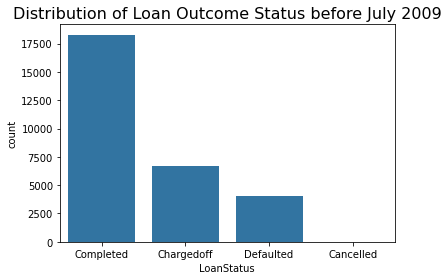

```python
base_color = sb.color_palette()[0]
loan_order = pre09['LoanStatus'].value_counts().index
sb.countplot( data = pre09, x = 'LoanStatus', color= base_color, order= loan_order)
plt.title('Distribution of Loan Outcome Status before July 2009', fontsize = 16);
```

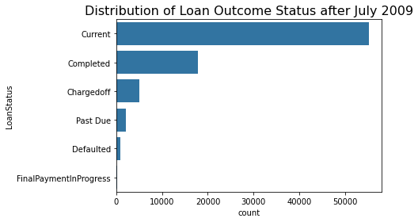

```python
base_color = sb.color_palette()[0]
loan_order = post09['LoanStatus'].value_counts().index
sb.countplot( data = post09, y = 'LoanStatus', color= base_color, order= loan_order)
plt.title('Distribution of Loan Outcome Status after July 2009', fontsize = 16);
```

**Bar chart showing outcome of loans after the year 2009 revealed that over 67% of total loans are yet to be paid, over 21% of total loans are completed and over 6% are Chargedoff.**

### Distribution of Interest Rate

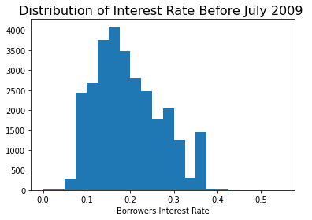

```python
bins = np.arange(0, pre09['BorrowerAPR'].max()+0.05, 0.025)
plt.hist(pre09['BorrowerAPR'], bins =bins)
plt.xlabel('Borrowers Interest Rate')
plt.title('Distribution of Interest Rate Before July 2009 ', fontsize =16);
```

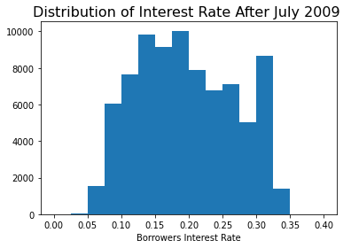

```python
bins = np.arange(0, post09['BorrowerRate'].max()+0.05, 0.025)
plt.hist(post09['BorrowerRate'], bins =bins)
plt.xlabel('Borrowers Interest Rate')
plt.title('Distribution of Interest Rate After July 2009 ', fontsize =16);
```

**Loan Outcome status Distribution shows that slightly over 63% of loans between the year 2005 and year 2009 has completed as status despite more than 50% of the data point having Interest Rate as high as 15% and above.**

**On the other hand, between the year 2009 and the year 2014 about 70% of loans has Loans Status as Current (i.e Loan repayment still in progress) while only about 22% are Completed. Interest rate having peaks around 10%, 15%, 20% and 30% region.** </font>

### Distribution of some Categorical Features

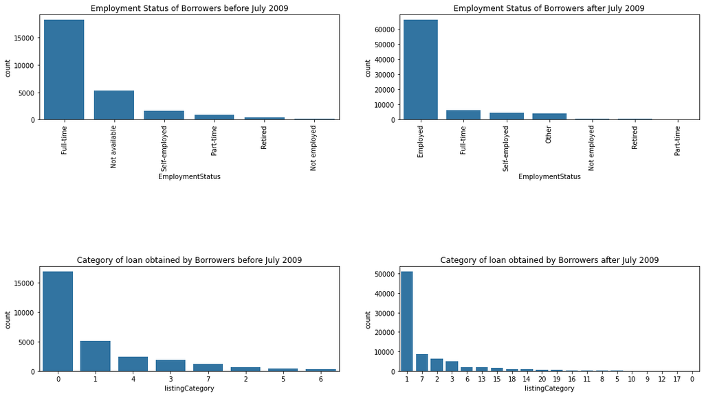

```python
#fig, ax = plt.subplots(nrows = 4, figsize=(8,8))
plt.figure(figsize=[18,10])

plt.subplot(3,2,1)
emp_order = pre09['EmploymentStatus'].value_counts().index
sb.countplot(data = pre09, x='EmploymentStatus', color=base_color, order=emp_order)
plt.title('Employment Status of Borrowers before July 2009')
plt.xticks(rotation=90)

plt.subplot(3,2,2)
emp_order = post09['EmploymentStatus'].value_counts().index
sb.countplot(data = post09, x='EmploymentStatus', color=base_color, order=emp_order)
plt.title('Employment Status of Borrowers after July 2009')
plt.xticks(rotation=90)

plt.subplot(3,2,5)
car_order = pre09['listingCategory'].value_counts().index
sb.countplot(data = pre09, x='listingCategory', color=base_color, order=car_order)
plt.title('Category of loan obtained by Borrowers before July 2009')

plt.subplot(3,2,6)
car_order=post09['listingCategory'].value_counts().index
sb.countplot(data = post09, x='listingCategory', color=base_color, order=car_order)
plt.title('Category of loan obtained by Borrowers after July 2009');
```

**Bar charts showing the employment status, listing category of borrowers for data pre09 and data post09 reveal that over 63% borrower are full time employee in data pre09 while over 80% borrower are Employed in data post09.**

**Also, for data pre09 over 58% borrowers purpse for the loans is not available while for data post09, over 63% of borrowers purpose for the loans is for Debt Consolidation.**

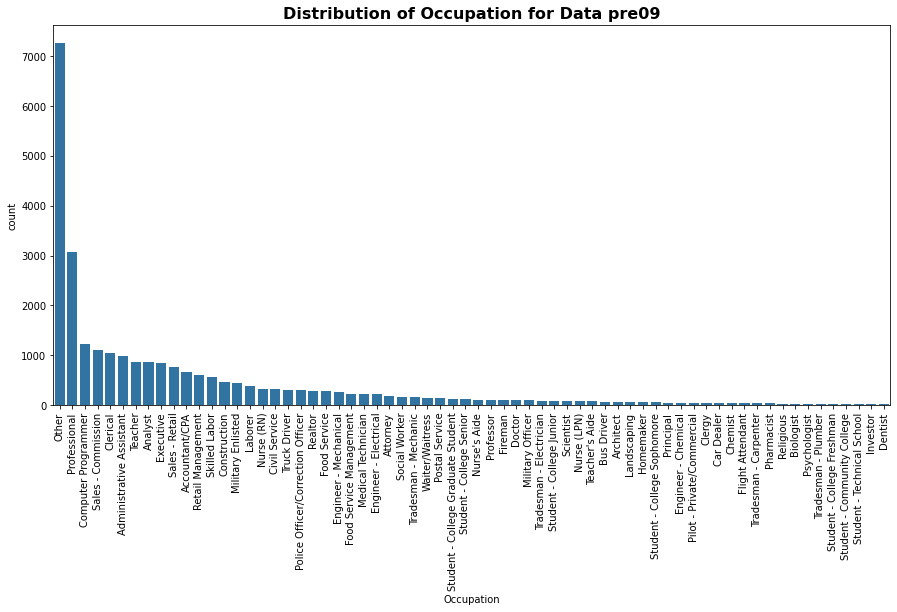

```python
plt.figure(figsize =(15,7))
occup_order = pre09['Occupation'].value_counts().index
sb.countplot(data = pre09, x ='Occupation', color =base_color, order=occup_order)
plt.xticks(rotation=90)
plt.title('Distribution of Occupation for Data pre09', fontsize =16, fontweight='bold');
```

**Bar chart shows that a large percent of the loans with years 2005-2009 are obtained by borrowers whose occupation are not known(other), follow by borrowers who are Professional, Computer Programmer e.t.c by profession**

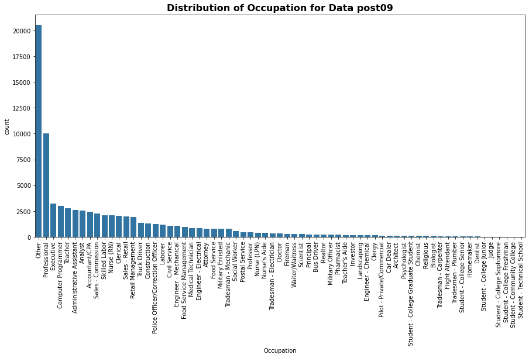

```python
plt.figure(figsize =(15,7))
occup_order = post09['Occupation'].value_counts().index
sb.countplot(data = post09, x ='Occupation', color =base_color, order=occup_order)
plt.xticks(rotation=90)
plt.title('Distribution of Occupation for Data post09', fontsize =16, fontweight='bold');
```

**Bar chart shows that a large percent of the loans with years 2010-2015 are obtained by borrowers whose occupation are not known(other), follow by borrowers who are Professional, Executive, Computer Programmer e.t.c by profession**

### Of the features you investigated, were there any unusual distributions? Did you perform any operations on the data to tidy, adjust, or change the form of the data? If so, why did you do this?

> The prosperscore variable has data that exceeds 10.0 which was the highest score a listing could have which implies that there is little to no risk of loss associated with the loan listed. Scores greater than 10.0 are treated as outliers and were removed

## Bivariate Exploration

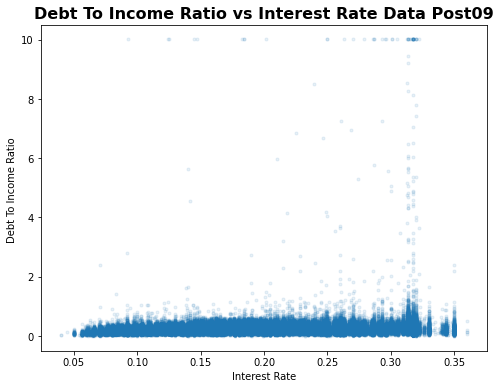

```python
plt.figure(figsize=(8,6))
plt.plot('BorrowerRate','DebtToIncomeRatio', data=post09, linestyle='', marker='o', markersize=3, alpha=0.1)
plt.xlabel('Interest Rate')
plt.ylabel('Debt To Income Ratio ')
plt.title('Debt To Income Ratio vs Interest Rate Data Post09', fontsize=16, fontweight='bold');
```

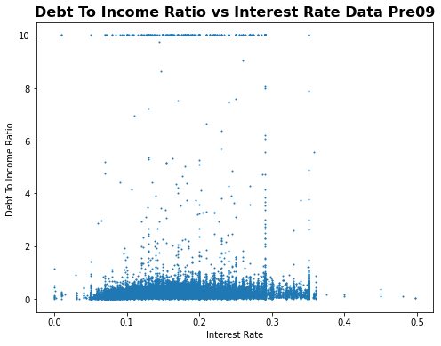

```python
plt.figure(figsize=(8,6))
plt.plot('BorrowerRate','DebtToIncomeRatio', data=pre09, linestyle='', marker='o', markersize=1)
plt.xlabel('Interest Rate')
plt.ylabel('Debt To Income Ratio ')
plt.title('Debt To Income Ratio vs Interest Rate Data Pre09', fontsize=16, fontweight='bold');
```

**Alot of borrowers Debt to Income ratio falls largely between 0 & 1 as shown from above plots**

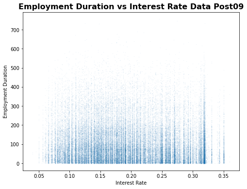

```python
plt.figure(figsize=(8,6))
plt.plot('BorrowerRate','EmploymentStatusDuration', data=post09, linestyle='', marker='o', markersize=0.5, alpha=0.07)
plt.xlabel('Interest Rate')
plt.ylabel('Employment Duration')
plt.title('Employment Duration vs Interest Rate Data Post09', fontsize=16, fontweight='bold');
```

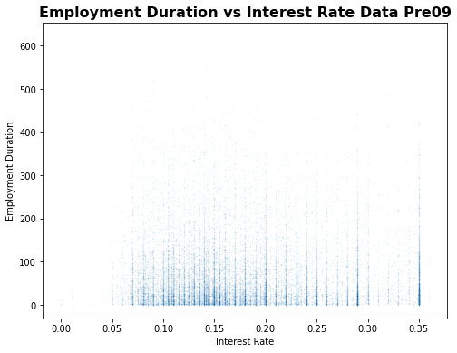

```python
plt.figure(figsize=(8,6))
plt.plot('BorrowerRate','EmploymentStatusDuration', data=pre09, linestyle='', marker='o', markersize=0.5, alpha=0.07)
plt.xlabel('Interest Rate')
plt.ylabel('Employment Duration')
plt.title('Employment Duration vs Interest Rate Data Pre09', fontsize=16, fontweight='bold');
```

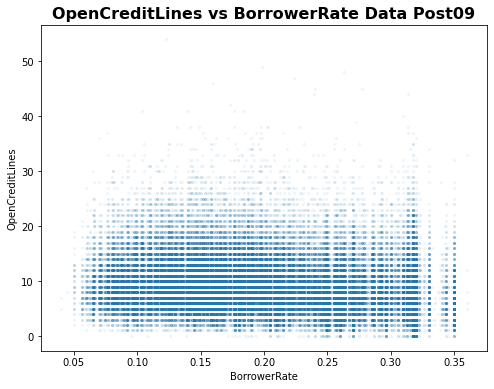

```python
plt.figure(figsize=(8,6))
plt.plot('BorrowerRate','OpenCreditLines', data=post09, linestyle='', marker='o', markersize=2, alpha=0.05)
plt.xlabel('BorrowerRate')
plt.ylabel('OpenCreditLines')
plt.title('OpenCreditLines vs BorrowerRate Data Post09', fontsize=16, fontweight='bold');
```

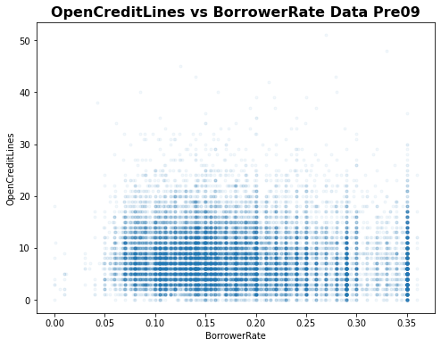

```python
plt.figure(figsize=(8,6))
plt.plot('BorrowerRate','OpenCreditLines', data=pre09, linestyle='', marker='o', markersize=3, alpha=0.05)
plt.xlabel('BorrowerRate')
plt.ylabel('OpenCreditLines')
plt.title('OpenCreditLines vs BorrowerRate Data Pre09', fontsize=16, fontweight='bold');
```

**The plots above shows that the number of Opened Credit lines by the borrowers seems to have a slight negative impact of the interent rate. While some borrowers with less than 10 credit line has interest rate less than 5%, few borrowers with credit lines greater than 20 do have interest rate greater than 25%**

```python
# list of quantitative features pre09

num_vari = ['BorrowerRate', 'DebtToIncomeRatio','AvailableBankcardCredit', 'CreditScoreRangeUpper',
            'EmploymentStatusDuration','OpenCreditLines','TotalTrades','RevolvingCreditBalance',
            'OpenRevolvingMonthlyPayment', 'OpenRevolvingAccounts','CurrentCreditLines']

# list of quantitative features post09

num_vari1 = ['BorrowerAPR', 'ProsperScore','AvailableBankcardCredit', 'CreditScoreRangeUpper', 'DebtToIncomeRatio',
        'EmploymentStatusDuration','OpenCreditLines','TotalTrades','RevolvingCreditBalance','OpenRevolvingMonthlyPayment',
       'OpenRevolvingAccounts','CurrentCreditLines','ProsperScore','ratingNumeric']

# list of qualitative features pre09
cat_vari=['LoanStatus','CreditGrade','EmploymentStatus','listingCategory']

# list of qualitative features post09
cat_vari1=['LoanStatus','ratingAlpha','EmploymentStatus','listingCategory']
```

### HeatMap of Quatitative variables in pre09 data

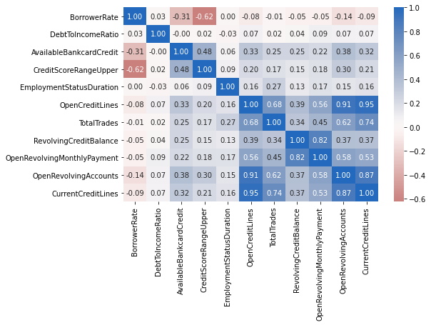

```python
plt.figure(figsize=(8,5))
sb.heatmap(pre09[num_vari].corr(), annot =True, fmt ='.2f', center=0, cmap='vlag_r', );
```

It is observed that there exist negative correlation of other quantitative variable with respect to BorrowerRate. I will try to apply log transform to other quantitative variable hopefully that helps with the correlation

```python
# list for continous variables

en=['BorrowerRate', 'DebtToIncomeRatio']
```

```python
# Applying Log Transform to other quantitative variables

vs = pre09[num_vari].apply(np.log10)
vs = pd.concat([pre09[en], vs], axis=1)
```

### HeatMap of Quatitative variables in pre09 data after Log Transform

[figure not shown]

```python
plt.figure(figsize=(8,5))
sb.heatmap(vs.corr(), annot =True, fmt ='.2f', center=0, cmap='vlag_r' );
```

### HeatMap of Quatitative variables in post09 data

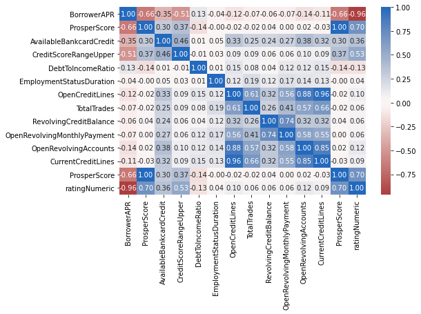

```python
plt.figure(figsize=(8,5))
sb.heatmap(post09[num_vari1].corr(), annot =True, fmt ='.2f', center=0, cmap='vlag_r' );
```

### Grid Pair plots of Quantitative Variables with 500 random data points for data pre09

Examining the effect of quantitative features on the borrower's interest rate.

- Question: What Variable likely to determine if borrower gets high interest rate or low interest rate?

```
pre09.shape= (28953, 43)
samp.shape= (500, 43)
```

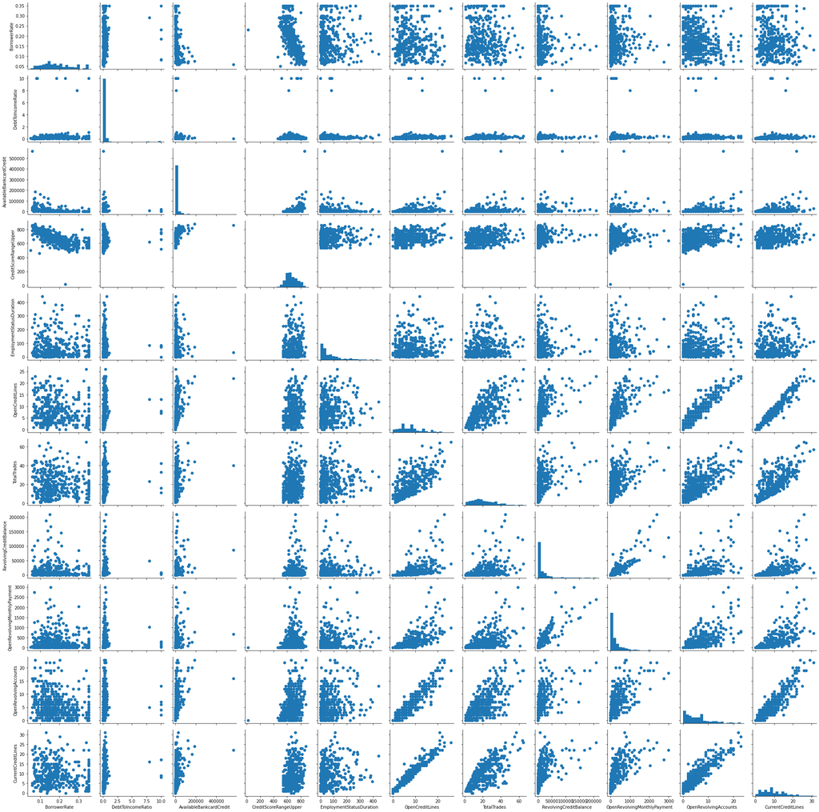

```python
# plot matrix: sample 500 observation

print("pre09.shape=",pre09.shape)
samp = pre09.sample(n=500, replace = False)
print("samp.shape=",samp.shape)

g = sb.PairGrid(data = samp, vars = num_vari)
g = g.map_diag(plt.hist, bins = 20);
g.map_offdiag(plt.scatter);
```